# TP3 : Gradients Stochastiques et Perceptrons

Author

Ema Cerezo

Published

October 10, 2023

## Les classifiers linéaires (affines)

### Question 1

On utilise les données suivantes :

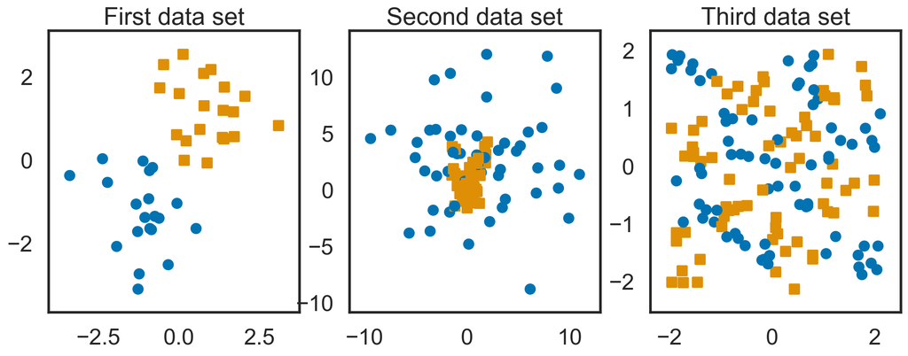

Il est aisé de séparer le premier jeu de données avec un séparateur linéaire : Il suffit de tracer une droite dans le cône entre les données bleues et les données oranges. En particulier, utiliser un SVM permettrait de maximiser la marge entre le séparateur et les données.

Il n’y a pas de très bon choix pour le second jeu de données.

Il est pratiquement impossible de séparer le troisième jeu de données avec un séparateur linéaire.

### Question 2

**a)** Le vecteur de prédiction est défini comme suit :

$$\hat f_w (x) := w_0 + \sum^p_{j=1} w_j x_j$$

La fonction `predict` de `tp_perceptron_source` renvoie : `np.dot(x, w[1:])+ w[0]`

Où, par cohérence avec la fonction `np.dot()` qui fait le produit de deux vecteurs (arrays), `x` est un vecteur de $\mathbb{R}^p$, `w[1:]` est un vecteur de $\mathbb{R}^p$, et `w[0]` est un réel (donc `w` est un vecteur de $\mathbb{R}^{p+1}$).

Mathématiquement, le produit scalaire de `x` ($x$) et `w[1:]` ($\omega = (w_1, ..., w_p)$) donne :

$$\langle x \; , \; \omega \rangle = \sum^p_{j=1} w_j x_j$$

Ainsi, en ajoutant ($w_0$) `w[0]`, on obtient bien :

$$\sum^p_{j=1} w_j x_j + w_0 = \hat f_w (x)$$

**b)** Par ailleurs, la fonction `predict_class(x, w)` renvoie : `np.sign(predict(x, w))`

Elle applique donc la fonction `sign` de `numpy`sur le vecteur de prédiction. Or, cette fonction renvoie `-1 if x < 0, 0 if x==0, 1 if x > 0`.

Ainsi, la fonction `predict_class(x, w)` renvoie bien l’étiquette prédite $sign(\hat f_w (x))$ dans les cas où $x \neq 0$, mais pas quand $x = 0$ (elle renvoie `0` au lieu de `1`) (cas très rare).

## Fonction de coût

### Question 3

On suppose que $x \in \mathbb{R}^p$ et $y \in \mathbb{R}$ sont fixes. On s’intéresse à la nature des fonctions de perte “pourcentage d’erreur”, “quadratique” et “hinge” (constante, linéaire, quadratique, constante par morceaux, linéaire par morceaux, quadratique par morceaux…).

**Pourcentage d’erreur :** $\text{ZeroOneLoss}(\hat f_w(x), y) = \frac{1}{2} |y − sign(\hat f_w(x))|$

Cette fonction est constante par morceaux.

**Quadratique :** $\text{MSELoss}(\hat f_w(x), y) = (y − \hat f_w(x))^2$

Cette fonction est quadratique.

**Hinge (charnière) :** $\text{HingeLoss}(\hat f_w(x), y) = max(0, 1 − y \cdot \hat f_w(x))$

Cette fonction est linéaire par morceaux.

### Question 4

gradient avec un batch = 1 La donnée est utilisée une fois par époque

On voudrait optimiser l’espérance de la perte mais trop couteux donc on optimise somme(l(f(x), y)) mais trop couteux donc on optimise juste l(f(x), y)

critère : les epsilon doivent être de carré sommable mais pas sommable (exemple 1/j)

Modification de l’algorithme pour avoir une version aléatoire :

```
while j ≤ niter do
    k <- vecteur contenant les entiers de 1 à n répartis aléatoirement
    for i in k do
        w ← w − ϵ∇wℓ(ˆfw(xi), yi)
    j ← j + 1
```

```
while j ≤ niter do
    for i = 1 to n do
        k <- nombre aléatoire entre 1 et n
        w ← w − ϵ∇wℓ( ˆfw(xk), yk)
    j ← j + 1
```

Correction :

Avec remise :

```
while  j ≤ niter * n do
    i0 <- rand([[1, n]])
    w <- w - ϵ∇wℓ( ˆfw(xi0), yi0)
    j ← j + 1
```

Sans remise:

```
while  j ≤ niter * n do
    p <- permutation_aléatoire([[1, n]])
    for i in p do:
        w <- w - ϵ∇wℓ( ˆfw(xi), yi)
    j ← j + 1
```

### Question 5

### Question 6

### Question 7

### Question 8

### Question 9

## Perceptron : linéaire… seulement ?

### Question 10

### Question 11

### Question 12